# Downloading Satellite Data from a THREDDS Server

Jason D Everett (UQ)

01/12/2020

# What is THREDDS

THREDDS (Thematic Realtime Environmental Distributed Data Services) data server (TDS) was developed by Unidata (UCAR) and allows for browsing, downloading and programmatically accessing scientific data. Data access is provided by OPeNDAP, OGC WMS and WCS, HTTP, and other remote data access protocols.

OPeNDAP is a protocol enabling data access and subsetting through the web.

Other protocols include:  
**NetCDF Subset Service (NCSS)**: Web service for subsetting files that can be read by the netCDF java library.  
**Web Map Service (WMS)**: OGC web service for requesting static images of data.  
**Web Coverage Service (WCS)**: OGC web service for requesting data in some output format.  
**HTTP File Download**: Direct downloading for files

# Finding a THREDDS catalog

Many data portals will have a THREDDS data server behind them. IMOS/AODN does for example: http://thredds.aodn.org.au/thredds/catalog/catalog.html

Other THREDDS catalogs include:  
**NCI**: http://dap.nci.org.au/thredds/catalog.html  
**NOAA**: https://data.nodc.noaa.gov/thredds/catalog.html  
**eReefs**: http://ereeftds.bom.gov.au/ereefs/tds/catalog.html  
**JPL**: https://opendap.jpl.nasa.gov/opendap/

Unfortuantely it is a bit hit and miss as to whether your data will be available by THREDDS, but its worth checking if you need to use large datasets which are easily subsettable.

# Using IMOS THREDDS for satellite data

You can find the AODN thredds catalog here:  
http://rs-data1-mel.csiro.au/thredds/catalog/imos-srs/catalog.html and  
http://thredds.aodn.org.au/thredds/catalog/catalog.html

Note that each have a ‘catalog.html’ extension. As you navigate around, you will notice that it is important to keep this intact to allow your web browser to find the html listing of files.

Now lets navigate through the directory structure to find some data. Go to http://rs-data1-mel.csiro.au/thredds/catalog/imos-srs/catalog.html (which has the satellite data).

Click: `oc` (Ocean Colour) -> `aqua` (MODIS Aqua Satellite) -> `12mNy` (Average of all data - 12 months, all years)

Notice the size of the files. Most are greater than 1 GB. Lots of data to download if you only want to use a small portion of the file.

Click on the Chl file with the oci algorithm.

You’ll see a page with a range of different DAPs (Data Access Protocols). We will use the OpenDAP protocol. Click on it.

Here you can see lots of information about the file. This is the metadata within the file itself. The beauty of netcdf files is that they store all the metadata about the variables, conversions, original files, processing information, along with the data itself. All the dimesions are named and references so you can access the data by dimensions easily. Have a look at the various infomation which is on this page.

You could subset the data from here by entering limits in the text boxes and downloading the data, but we don’t want to do this because it won’t be reproducible. We want all our science to be reproducible. Instead we are going to use the actual data location (Data URL) to query and download what we want. http://rs-data1-mel.csiro.au/thredds/dodsC/imos-srs/oc/aqua/12mNy/2003-2019.01-12.chl_oci_mean_mean_mean.nc

## Downloading and Plotting a spatial map.

Start with the required libraries

```r
library(tidync)
library(raster)
library(sf)
library(lubridate)
library(rnaturalearth)
library(tidyverse)
```

Setup the download parameters

```r
dat <- tibble(Lat_Min = -30,
              Lat_Max = -5,
              Lon_Min = 140,
              Lon_Max = 160)

imos_url <- "http://rs-data1-mel.csiro.au/thredds/dodsC/imos-srs/oc/aqua/12mNy/2003-2019.01-12.chl_oci_mean_mean_mean.nc"
```

Now use tidync to subset and download the netcdf file.

```r
out <- tidync(imos_url) %>% # The filename (local or online)
  hyper_filter(longitude = longitude >= dat$Lon_Min & longitude <= dat$Lon_Max, # nc files on thredds can be subset
               latitude = latitude >= dat$Lat_Min & latitude <= dat$Lat_Max) %>%
  hyper_tibble(select_var = "chl_oci_mean_mean_mean") %>%
  rename(Chl = chl_oci_mean_mean_mean)# which variable and format to return
```

Now plot the spatial output.

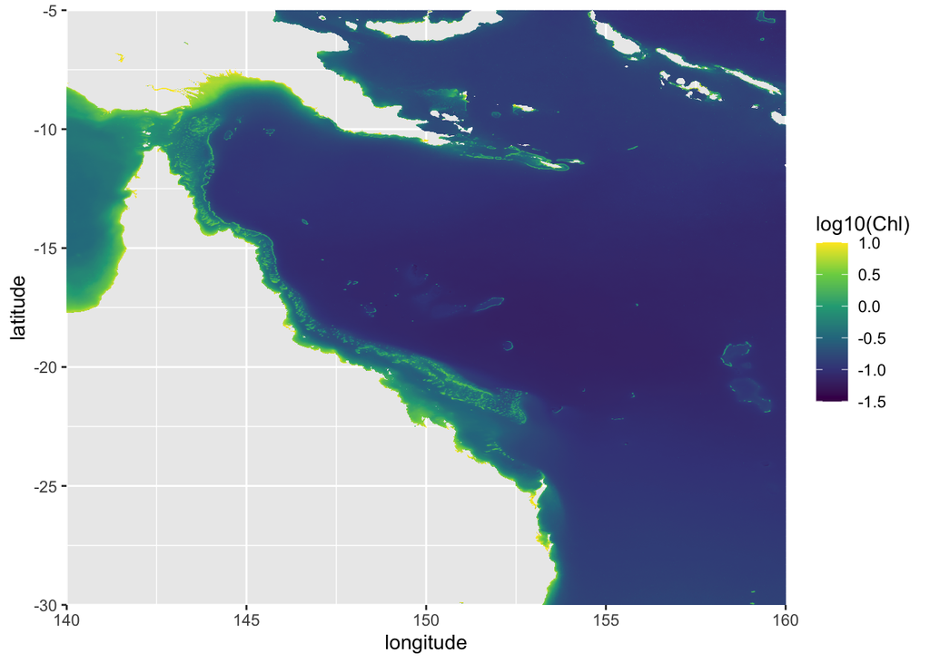

```r
(gg <- ggplot(data = out, aes(x = longitude, y = latitude, fill = log10(Chl))) +
    geom_tile() +
    scale_fill_continuous(type = "viridis", limits = c(-1.5, 1), oob = scales::squish) +
  scale_x_continuous(expand = c(0,0)) +
  scale_y_continuous(expand = c(0,0)))
```

The geographic scale is a bit wonky because of the large range of latitude we are working over.

A better approach would be to map the data. We can do that by converting the dataframe to an `sf` object. Here we also demonstrate the `hyper_array` which is much more memory friendly.

Lets start by downloading the data so we can start afresh.

```r
out <- tidync(imos_url) %>% # The filename (local or online)
  hyper_filter(longitude = longitude >= dat$Lon_Min & longitude <= dat$Lon_Max, # nc files on thredds can be subset
               latitude = latitude >= dat$Lat_Min & latitude <= dat$Lat_Max) %>%
  hyper_array(select_var = "chl_oci_mean_mean_mean")
```

Then we concert the `hyper_array` (essentially a matrix) to a `raster` object, then to an `sf` object. The reason I convert to a raster is so we can change from spatial data points to polygons which are much nicer to plot (There are other ways to do this but I find teh slightly convoluted way to be the easiest and fastest).

```r
r_sf <- raster(t(out$chl_oci_mean_mean_mean),xmn=dat$Lon_Min, xmx=dat$Lon_Max, ymn=dat$Lat_Min, ymx=dat$Lat_Max, crs = "+proj=longlat +datum=WGS84") %>%
  aggregate(4, fun=mean) %>%
  rasterToPolygons() %>%
  st_as_sf(coords = c("x", "y")) %>%
  drop_na()
```

Now lets plot it as before, but this time we use `geom_sf` which deals with the spatial data, using the correct projection, and getting the aspect ratio correct. Adding the land makes it look pretty. For this we can use the `rnaturalearth` package.

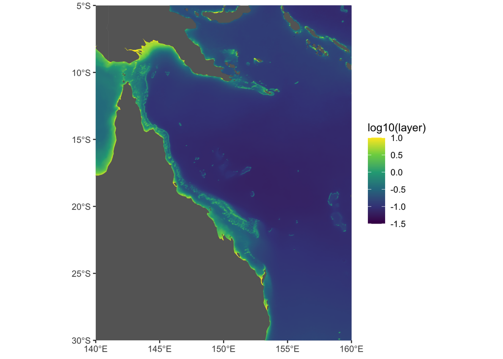

```r
world_sf <- ne_countries(scale = "medium", returnclass = "sf") # Add land

ggplot() +
  geom_sf(data = r_sf, aes(colour = log10(layer))) + # Satellite data
  geom_sf(data = world_sf, size = 0.05, fill = "grey40") + # Land data
  scale_colour_continuous(type = "viridis", limits = c(-1.5, 1), oob = scales::squish) +
  scale_x_continuous(limits = c(dat$Lon_Min, dat$Lon_Max), expand = c(0,0)) +
  scale_y_continuous(limits = c(dat$Lat_Min, dat$Lat_Max), expand = c(0,0))
```

# Downloading a Timeseries

Where thredds servers come into their own, is when you need to download lots of small parcels of data. Rather than downloading 100 files of 1GB each, we can download 100 timesteps of a few KBs.

This time lets do SST. We will download 4 years of monthly data at the North Stradbroke Island NRS.

Similar to before, we will define the range in the advance, but this time we will take an average of the pixels around the NRS.

First lets go back to the AODN satellite page so we can get the actual url we need. Start at: http://rs-data1-mel.csiro.au/thredds/catalog/imos-srs/catalog.html

```r
# NRS Location
NRS_Lon <- 153.562
NRS_Lat <- -27.345

# Create a tibble to save all the info together
dat <- tibble(Lat_Min = NRS_Lat - 0.01,
              Lat_Max = NRS_Lat + 0.01,
              Lon_Min = NRS_Lon - 0.01,
              Lon_Max = NRS_Lon + 0.01,
              Date_Min = ymd("2003-01-01"),
              Date_Max = ymd("2007-01-01"),)

n_mths <- interval(dat$Date_Min,dat$Date_Max) %/% months(1) # How many months in the date range
all_dates <- dat$Date_Min + months(0:(n_mths-1)) # A vector of all dates
out <- tibble(Date = all_dates, SST = NA) # Create a dataframe with preallocated slots
```

No lets loop through the months to get the data.

Unfortunately the IMOS data is stored as Lon x Lat with time in a new file so we have to download each date individually. Some datasets will be stored as a data-cube (Data stored as Lon x Lat x Time) meaning we can get all times from the same location at once.

Here we are downloading data from the same location to create a time-series. You can also use this approach to get satellite/model data for a target which is moving in time and space, such as a research voyage, a CPR, a tagged animal or a glider. Anything which has a time, lat and lon reference.

```r
for (t in 1:n_mths){

    mth <- str_pad(month(all_dates[t]),2,"left", pad="0")
    yr <- year(all_dates[t])

  imos_url <- paste0("http://rs-data1-mel.csiro.au/thredds/dodsC/imos-srs/oc/aqua/1m/",yr,"/",yr, mth,".sst.nc")

  print(paste0("Downloading Year = ",yr, " and Month = ",mth,""))

   temp <- tidync(imos_url) %>% # The filename (local or online)
    hyper_filter(longitude = longitude >= dat$Lon_Min & longitude <= dat$Lon_Max, # nc files on thredds can be subset
               latitude = latitude >= dat$Lat_Min & latitude <= dat$Lat_Max) %>%
    hyper_tibble(select_var = "sst_mean") %>%
    group_by(time) %>%
    summarise(sst_mean = mean(sst_mean, na.rm = TRUE))

  out$SST[t] <- temp$sst_mean
  rm(temp)

}
```

```
## [1] "Downloading Year = 2003 and Month = 01"
## [1] "Downloading Year = 2003 and Month = 02"
## [1] "Downloading Year = 2003 and Month = 03"
## [1] "Downloading Year = 2003 and Month = 04"
## [1] "Downloading Year = 2003 and Month = 05"
## [1] "Downloading Year = 2003 and Month = 06"
## [1] "Downloading Year = 2003 and Month = 07"
## [1] "Downloading Year = 2003 and Month = 08"
## [1] "Downloading Year = 2003 and Month = 09"
## [1] "Downloading Year = 2003 and Month = 10"
## [1] "Downloading Year = 2003 and Month = 11"
## [1] "Downloading Year = 2003 and Month = 12"
## [1] "Downloading Year = 2004 and Month = 01"
## [1] "Downloading Year = 2004 and Month = 02"
## [1] "Downloading Year = 2004 and Month = 03"
```

[output cut: 33 more lines]

## Plot Timeseries

Now we can plot the satellite time series.

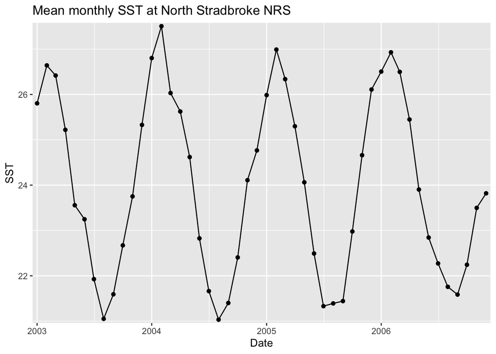

```r
(gg_sst <- ggplot(data = out, aes(x = Date, y = SST)) +
  geom_point() +
  geom_line() +
  ggtitle("Mean monthly SST at North Stradbroke NRS") +
  scale_x_date(expand = c(0.01,0.01)) +
  scale_y_continuous(expand = c(0.01,0.01)))
```